# Bivariate Disease Mapping

Leiwen Gao, Sudipto Banerjee

6/15/2021

### 1. Load California map and packages

```r
##### Libraries for sptial information in map, map projection and map ploting
library(maps)
#Import California map with counties
ca.county = map("county","california", fill=TRUE, plot=FALSE)
library(mapproj)
library(spdep)
library(maptools)
library(classInt)
library(RColorBrewer)

##### Libraries for matrix, distribution and math computation
library(mvtnorm)
library(matrixStats)
library(blockmatrix)
library(Matrix)
library(invgamma)
library(MASS)

##### Libraries for JAGS
library(rjags)
library(R2jags)

##### Data management
library(tidyr)

##### Import and export documents
library(knitr)
library(readr)

##### Bayesian inference
library(LaplacesDemon)
```

### 2. Dataset exploration and visualization

#### 2.1 Import dataset (county-level) extracted from SEER

Cancers: lung (ICD-O-3: C340-C349) and esophagus (ICD-O-3: C150-C159)

Outcome: 5-year average crude incidence rates per 100,000 population in the years from 2012 to 2016

Covariates (percentage): adult cigarette smoking rates, percentages of residents younger than 18 years old, older than 65 years old, with education level below high school, percentages of unemployed residents, black residents, male residents, uninsured residents, and percentages of families below the poverty threshold

```r
crude_rate_5y <- read.csv("data/crude_rate.csv")
covariates <- read.csv("data/county_attributes.csv")
race <- read.csv("data/race.csv")
sex <- read.csv("data/sex.csv")
insurance <- read.csv("data/insurance.csv")
smoking <- read.csv("data/smoking.csv")
smoking$smoking <- as.numeric(substr(smoking$Cigarette.Smoking.Rate., 1,4))

crude_rate_CA = crude_rate_5y[substr(crude_rate_5y$State_county,1,2) == "CA",]
crude_rate_lung = crude_rate_CA[crude_rate_CA$Site_recode_ICD_O_3_WHO_2008=="Lung and Bronchus",]
crude_rate_lung = crude_rate_lung[order(extract_numeric(crude_rate_lung$State_county)),]

crude_rate_esophagus = crude_rate_CA[crude_rate_CA$Site_recode_ICD_O_3_WHO_2008=="Esophagus",]
crude_rate_esophagus = crude_rate_esophagus[order(extract_numeric(crude_rate_esophagus$State_county)),]

county_attribute = covariates[substr(covariates$State_county,1,2) == "CA",]
county_attribute$state = extract_numeric(county_attribute$State_county)
county_attribute1 = data.frame(county_attribute[order(county_attribute$state),])
county_attribute1$V_Persons_age_18_ACS_2012_2016 = as.numeric(county_attribute1$V_Persons_age_18_ACS_2012_2016)/100
county_attribute1$V_Persons_age_65_ACS_2012_2016 = as.numeric(county_attribute1$V_Persons_age_65_ACS_2012_2016)/100
county_attribute1$VHighschooleducationACS2012201 = as.numeric(county_attribute1$VHighschooleducationACS2012201)/100
county_attribute1$VFamiliesbelowpovertyACS201220 = as.numeric(county_attribute1$VFamiliesbelowpovertyACS201220)/100
county_attribute1$V_Unemployed_ACS_2012_2016 = as.numeric(county_attribute1$V_Unemployed_ACS_2012_2016)/100

race1 = race[substr(race$State_county,1,2) == "CA"&race$Race_recode_White_Black_Other=="Black",]
sex1 = sex[substr(sex$State_county,1,2) == "CA"&sex$Sex=="Male",]
insurance1 = insurance[substr(insurance$State_county,1,2) == "CA"&insurance$Insurance_Recode_2007=="Uninsured",]

crude_rate_lung1 = cbind(crude_rate_lung, smoking$smoking, county_attribute1[,2:6], race1$Row_Percent, sex1$Row_Percent,insurance1$Row_Percent)
colnames(crude_rate_lung1) = c("county", "site", "rate", "count", "population", "smoking", "young","old", "highschool", "poverty", "unemployed", "black", "male", "uninsured")

crude_rate_esophagus1 = cbind(crude_rate_esophagus, smoking$smoking, county_attribute1[,2:6], race1$Row_Percent, sex1$Row_Percent,insurance1$Row_Percent)
colnames(crude_rate_esophagus1) = c("county", "site", "rate", "count", "population", "smoking", "young","old", "highschool", "poverty", "unemployed", "black", "male", "uninsured")
```

#### 2.2 Combine cancer data with the California map for each county

To plot the cancer data, we need to combine the data with the map polygon

```r
county.ID <- sapply(strsplit(ca.county$names, ","), function(x) x[2])
ca.poly = map2SpatialPolygons(ca.county, IDs=county.ID)
ca.poly$rate_lung = crude_rate_lung$Crude_Rate
ca.poly$rate_esophagus = crude_rate_esophagus$Crude_Rate
ca.poly$smoking = smoking$smoking
```

#### 2.3 Plots for raw incidence data and important covariates

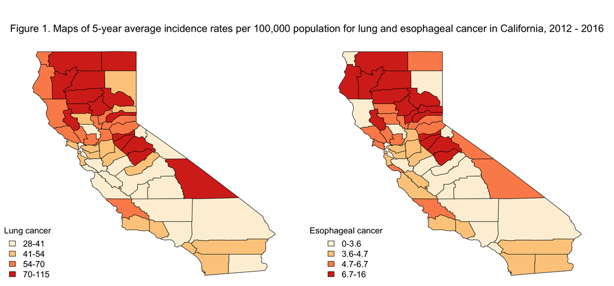

```r
###### Figure 1: Plot for raw incidence data ############
brks_fit_lung = c(28, 41, 54, 70, 115)
brks_fit_esophagus = c(0, 3.6, 4.7, 6.7, 16)
ca.poly$rate_lung = crude_rate_lung$Crude_Rate
ca.poly$rate_esophagus = crude_rate_esophagus$Crude_Rate
class.rate_lung = classIntervals(var=ca.poly$rate_lung, n=4, style="fixed",
                                 fixedBreaks=brks_fit_lung, dataPrecision=4)
class.rate_esophagus = classIntervals(var=ca.poly$rate_esophagus, n=4, style="fixed",
                                      fixedBreaks=brks_fit_esophagus, dataPrecision=4)
color.pallete = brewer.pal(4,"OrRd")
color.code.rate_lung = findColours(class.rate_lung, color.pallete)
color.code.rate_esophagus = findColours(class.rate_esophagus, color.pallete)


par(mfrow=c(1,2), oma = c(0,0,4,0) + 0.1, mar = c(0,0,1,0) + 0.1)

plot(ca.poly, col = color.code.rate_lung)
leg.txt1 = c("28-41", "41-54", "54-70","70-115")
legend("bottomleft", title="Lung cancer", legend=leg.txt1, cex=1.25, bty="n", horiz = FALSE,
       fill = color.pallete)

plot(ca.poly, col = color.code.rate_esophagus)
leg.txt2 = c("0-3.6", "3.6-4.7", "4.7-6.7", "6.7-16")
legend("bottomleft", title="Esophageal cancer",legend=leg.txt2, cex=1.25, bty="n", horiz = FALSE,
       fill = color.pallete)
mtext("Figure 1. Maps of 5-year average incidence rates per 100,000 population for lung and esophageal cancer in California, 2012 - 2016", outer = TRUE, cex = 1.5)
```

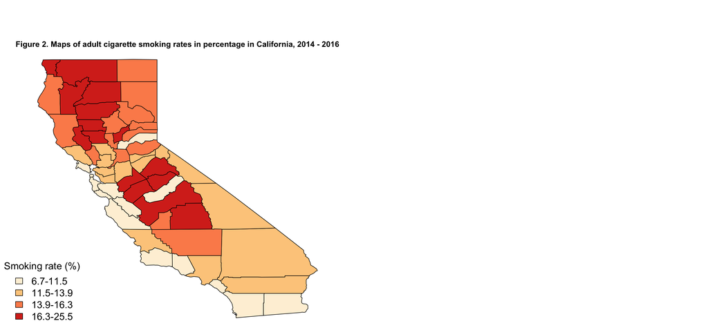

```r
###### Figure 2: Plot for smoking rates ############
brks_smoking = quantile(smoking$smoking)

class.rate_smoking = classIntervals(var=ca.poly$smoking, n=4, style="fixed",
                                 fixedBreaks=brks_smoking, dataPrecision=4)

color.pallete = brewer.pal(4,"OrRd")
color.code.rate_smoking = findColours(class.rate_smoking, color.pallete)

plot(ca.poly, col = color.code.rate_smoking,
     main = "Figure 2. Maps of adult cigarette smoking rates in percentage in California, 2014 - 2016",
     cex.main=1)
leg.txt1 = c("6.7-11.5", "11.5-13.9", "13.9-16.3","16.3-25.5")
legend("bottomleft", title="Smoking rate (%)", legend=leg.txt1, cex=1.25, bty="n", horiz = FALSE,
       fill = color.pallete)
```

#### 2.4 Create adjacency matrix for spatial information in directed graph

The matrix ``Adj’’ is the adjacency matrix for counties in California. We reorder the counties starting from northwest to southeast for directed graph. Then we put all the islands (counties with no parent neighbors) at the beginning.

```r
ca.neighbors = poly2nb(ca.poly)
n=length(ca.neighbors)

# original adjacency matrix
Adj=sapply(ca.neighbors,function(x,n) {v=rep(0,n);v[x]=1;v},n)
colnames(Adj)=county.ID
ca.coord = coordinates(ca.poly)
ca.latrange=round(quantile(ca.coord[,2],c(0.25,0.75)))
ca.albersproj=mapproject(ca.coord[,1],ca.coord[,2],projection = "albers",param=ca.latrange)

# reorder counties from northwest to southeast
perm=order(ca.albersproj$x-ca.albersproj$y)
Adj_new=Adj[perm,perm]

n=nrow(Adj_new)
ni=rowSums(Adj_new)
maxn=max(ni)
neimat=matrix(0,n,maxn)
neighbors=lapply(1:n,function(x) which(Adj_new[x,]==1))
dneighbors=sapply(2:n,function(i) intersect(neighbors[[i]],1:(i-1)))
dni=sapply(dneighbors,length)
original_perm = 1:58
index2=c(1,which(dni==0)+1)

# final permutation for counties: put all the islands (counties with no parent neighbors) at the beginning
final_perm=c(original_perm[perm][index2],
             original_perm[perm][-index2])
colnames(Adj)[final_perm]
```

```
##  [1] "del norte"       "san francisco"   "humboldt"        "siskiyou"
##  [5] "trinity"         "shasta"          "modoc"           "mendocino"
##  [9] "tehama"          "glenn"           "lake"            "lassen"
## [13] "colusa"          "butte"           "sonoma"          "plumas"
## [17] "napa"            "sutter"          "yuba"            "marin"
## [21] "yolo"            "sierra"          "nevada"          "solano"
## [25] "placer"          "sacramento"      "contra costa"    "san mateo"
## [29] "el dorado"       "alameda"         "amador"          "san joaquin"
## [33] "santa cruz"      "calaveras"       "santa clara"     "alpine"
## [37] "stanislaus"      "tuolumne"        "merced"          "mariposa"
## [41] "san benito"      "monterey"        "mono"            "madera"
## [45] "fresno"          "kings"           "san luis obispo" "tulare"
## [49] "santa barbara"   "inyo"            "kern"            "ventura"
## [53] "los angeles"     "orange"          "san bernardino"  "riverside"
## [57] "san diego"       "imperial"
```

```r
Minc = Adj[final_perm,final_perm]
n=nrow(Minc)
ni=rowSums(Minc)
maxn=max(ni)
neimat=matrix(0,n,maxn)
neighbors=lapply(1:n,function(x) which(Minc[x,]==1))
#directed or parent neighbors
dneighbors=sapply(2:n,function(i) intersect(neighbors[[i]],1:(i-1)))
dni=sapply(dneighbors,length)
nmax=max(dni)
cni=cumsum(dni)
dneimat=sapply(dneighbors, function(nei,nmax,n) c(nei,rep(n+1,nmax+1-length(nei))),nmax,n)
udnei=unlist(dneighbors)
ni_wo = sapply(neighbors,length)
cni_wo = cumsum(ni_wo)
udnei_wo = unlist(neighbors)
```

### 3. Hierarchical Models for multivariate areal data implemented in JAGS

We’ll use two methods, BDAGAR and GAMCAR, to analyze the bivariate areal data for lung and esophageal cancer. It may take a few minutes for models running in JAGS.

#### 3.1 Create response vector and covariate matrix in regression for each cancer

Reorder the data with the new order of counties

```r
Y1 = crude_rate_lung1$rate[final_perm]
Y2 = crude_rate_esophagus1$rate[final_perm]

X1 = as.matrix(cbind(1,crude_rate_lung1[,6:14]))[final_perm,]
X2 = as.matrix(cbind(1,crude_rate_esophagus1[,6:14]))[final_perm,]
```

#### 3.2 Different orders for cancers

For two cancers, there are two orders:

Model 1 (disease 1, disease 2): disease 1 $\times$ [disease 2 | disease 1]

Model 2 (disease 2, disease 1): disease 2 $\times$ [disease 1 | disease 2].

In this example, disease 1 is lung cancer and disease 2 is esphageal cancer

```r
#Model1 : lung, esophagus
Y.o1 = c(Y1,Y2)
X.o1 = as.matrix(bdiag(X1, X2))

#Model2 : esophagus, lung
Y.o2 = c(Y2,Y1)
X.o2 = as.matrix(bdiag(X2, X1))
```

#### 3.3 Method 1: Bivariate Directed Acyclic Graph Auto-regressive (BDAGAR) Model

The model is saved as a text file and will be run in JAGS.

```
sink("BDAGAR.txt")
cat("
    model
    {
    for(i in 1:2){
    Tau1[i, i] <- 1
    Tau2[i, i] <- 1

    for(j in 1:k){
    B1[i,j] <- 0
    B2[i,j] <- 0
    }
    }

    for(l in 1:(k-1)){
    for(h in (l+1):k){
    Tau1[l,h] <- 0
    Tau2[l,h] <- 0
    }
    }

    Tau1[2,1] <- 0
    Tau2[2,1] <- 0

    for (i in 3:k)
    {
    Tau1[i,i] <- (1 + (ns[i-1] - 1) * rho1^2) / (1 - rho1^2)
    Tau2[i,i] <- (1 + (ns[i-1] - 1) * rho2^2) / (1 - rho2^2)
    for(h in 1:(i-1)){
    Tau1[i,h] <- 0
    Tau2[i,h] <- 0
    }
    b1[i] <- rho1 / (1 + (ns[i-1] - 1) * rho1^2)
    b2[i] <- rho2 / (1 + (ns[i-1] - 1) * rho2^2)
    #neighbor regions for region i with coef b
    for(j in (udnei[(cn[i-1] + 1):(cn[i-1] + ns[i-1])])){
    B1[i,j] <- b1[i]
    B2[i,j] <- b2[i]
    }
    #regions which are not neighbors for region i with b = 0
    for(j in index1[(k*(i-3)-cn[i-1]+1) : (k*(i-3)-cn[i-1] + (k - ns[i-1]))]){
    B1[i,j] <- 0
    B2[i,j] <- 0
    }
    }

    Q1 <- t(I - B1) %*% Tau1 %*% (I - B1)
    Q2 <- t(I - B2) %*% Tau2 %*% (I - B2)

    W1[1:k] ~ dmnorm(rep(0, k), tau1*Q1)
    W2[1:k] ~ dmnorm(rep(0, k), tau2*Q2)

    A21 <- eta021 * I + eta121 * Minc

    W[1:k] <- W1
    W[(k+1):(2*k)] <- A21 %*% W1 + W2

    for (i in 1:k)
    {
    mu[i] <- X[i,] %*% beta + W[i]
    Y[i] ~ dnorm(mu[i], taue1)
    }

    for (i in (k+1):(2*k))
    {
    mu[i] <- X[i,] %*% beta + W[i]
    Y[i] ~ dnorm(mu[i], taue2)
    }

    rho1 ~ dunif(0, 0.999)
    rho2 ~ dunif(0, 0.999)
    tau1 ~ dgamma(2, 0.1)
    tau2 ~ dgamma(2, 0.1)
    eta021 ~ dnorm(0, 0.01)
    eta121 ~ dnorm(0, 0.01)
    taue1 ~ dgamma(2, 1)
    taue2 ~ dgamma(2, 1)
    vare1 <- 1/taue1
    vare2 <- 1/taue2
    beta[1:nc] ~ dmnorm(rep(0,nc), (0.001*I1))
    }
    ", fill = TRUE)
sink()
```

##### 3.3.1 Run BDAGAR in JAGS and obtain the MCMC Outputs

```r
region = seq(1:n)
cn = c(0, cni)
ns = dni

index = list()
#the first two regions have no parent neighbors
for(i in 1:(n-2)){
  #regions not belong to the neighbors of region i
  index[[i]] = region[-(udnei[(cn[i+1] + 1):(cn[i+1] + ns[i+1])])]
}
index1 = unlist(index)

model.data1 <- list(k = n, nc = ncol(X.o1), index1 = index1, I = diag(n), I1 = diag(ncol(X.o1)), Minc = Minc, ns = dni, cn = c(0, cni), udnei = udnei, X = X.o1, Y = Y.o1)
model.data2 <- list(k = n, nc = ncol(X.o2), index1 = index1, I = diag(n), I1 = diag(ncol(X.o2)), Minc = Minc, ns = dni, cn = c(0, cni), udnei = udnei, X = X.o2, Y = Y.o2)
model.inits <- rep(list(list(rho1 = 0.1, rho2 = 0.1,  tau1 = 1, tau2 = 1, eta021 = 1,
                             eta121 = 1, taue1 = 1, taue2 = 1,
                             beta = rep(0, ncol(X.o1)), W1 = rep(0.1, n),
                             W2 = rep(0.1, n))),1)
model.param <- c("beta", "rho1", "rho2", "tau1", "tau2", "eta021", "eta121",
                 "vare1", "vare2", "W")
```

Model 1: esophagus | lung

```r
set.seed(123)
#Model1 result: esophagus | lung
estimate1 <- jags(model.data1, model.inits, model.param, "BDAGAR.txt",
                  n.chains = 1, n.iter = 30000,n.burnin = 15000, n.thin = 1)
W_mcmc.m1 = estimate1$BUGSoutput$sims.array[,1,1:116]
```

Model 2: lung | esophagus

```r
#Model2 result: lung | esophagus
set.seed(123)
estimate2 <- jags(model.data2, model.inits, model.param, "BDAGAR.txt",
                  n.chains = 1, n.iter = 30000,n.burnin = 15000, n.thin = 1)
W_mcmc.m2 = estimate2$BUGSoutput$sims.array[,1,1:116]
```

##### 3.3.2 Calculate WAIC for model comparion

Model 1: esophagus | lung

```r
#Model 1
W1_mcmc = W_mcmc.m1[,1:58]
W2_mcmc = W_mcmc.m1[,59:116]

sample.mcmc1 = estimate1$BUGSoutput$sims.array[,1,c(117:136,144:145)]

PL_single <- matrix(0, nrow = 2*n, ncol = 15000)
for(i in 1:15000){
  #print(i)
  theta <- sample.mcmc1[i,]

  beta1 <- theta[1:10]
  beta2 <- theta[11:20]
  sigmasq1 <- theta[21]
  sigmasq2 <- theta[22]

  PL_single[1:58,i] <- unlist(rep(-1/2*log(2*pi) - 1/2*log(sigmasq1), n)) - unlist(rep(1/(2*sigmasq1),n))*(Y1-X1%*%as.vector(beta1) - W1_mcmc[i,])^2
  PL_single[59:116,i] <- unlist(rep(-1/2*log(2*pi) - 1/2*log(sigmasq2), n)) - unlist(rep(1/(2*sigmasq2),n))*(Y2-X2%*%as.vector(beta2) - W2_mcmc[i,])^2
}

waic_dagar1 = WAIC(PL_single)
waic_dagar1
```

```
## $WAIC
## [1] 613.2653
##
## $lppd
## [1] -261.3109
##
## $pWAIC
## [1] 45.32175
##
## $pWAIC1
## [1] 31.97932
```

Model 2: lung | esophagus

```r
#Model 2
W1_mcmc = W_mcmc.m2[,1:58]
W2_mcmc = W_mcmc.m2[,59:116]

sample.mcmc2 = estimate2$BUGSoutput$sims.array[,1,c(117:136,144:145)]

PL_single <- matrix(0, nrow = 2*n, ncol = 15000)
for(i in 1:15000){
  #print(i)
  theta <- sample.mcmc2[i,]

  beta1 <- theta[1:10]
  beta2 <- theta[11:20]
  sigmasq1 <- theta[21]
  sigmasq2 <- theta[22]

  PL_single[1:58,i] <- unlist(rep(-1/2*log(2*pi) - 1/2*log(sigmasq1), n)) - unlist(rep(1/(2*sigmasq1),n))*(Y2-X2%*%as.vector(beta1) - W1_mcmc[i,])^2
  PL_single[59:116,i] <- unlist(rep(-1/2*log(2*pi) - 1/2*log(sigmasq2), n)) - unlist(rep(1/(2*sigmasq2),n))*(Y1-X1%*%as.vector(beta2) - W2_mcmc[i,])^2
}

waic_dagar2 = WAIC(PL_single)
waic_dagar2
```

```
## $WAIC
## [1] 413.6839
##
## $lppd
## [1] -155.1196
##
## $pWAIC
## [1] 51.72228
##
## $pWAIC1
## [1] 36.75242
```

##### 3.3.3 Posterior distribution of $\eta_{0}$ and $\eta_{1}$ for two models

$\eta_{0}$ and $\eta_{1}$ are linking parameters to associate two cancers

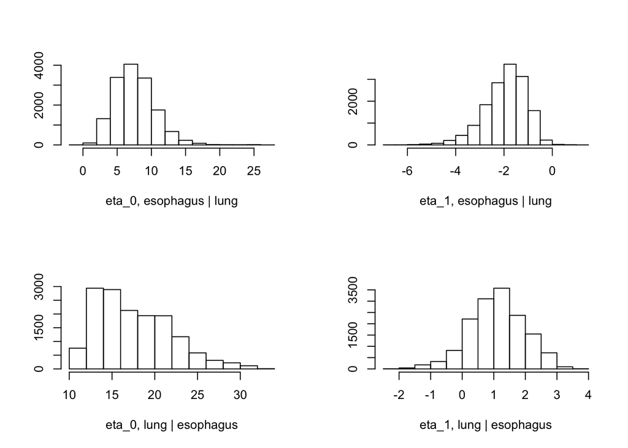

```r
par(mfrow=c(2,2))
hist(estimate1$BUGSoutput$sims.array[,1,138],xlab = "eta_0, esophagus | lung",ylab = "", main="")
hist(estimate1$BUGSoutput$sims.array[,1,139],xlab = "eta_1, esophagus | lung",ylab = "", main="")
hist(estimate2$BUGSoutput$sims.array[,1,138],xlab = "eta_0, lung | esophagus",ylab = "", main="")
hist(estimate2$BUGSoutput$sims.array[,1,139],xlab = "eta_1, lung | esophagus",ylab = "", main="")
```

#### 3.4 Method 2: Generalized Multivariate Conditional Auto-regressive (GMCAR) Model

The model is saved as a text file and will be run in JAGS.

```
sink("GMCAR.txt")
cat("
    model
    {
    Q1[1:k, 1:k] <- tau1*(D - rho1*Minc)
    Q2[1:k, 1:k] <- tau2*(D - rho2*Minc)

    W1[1:k] ~ dmnorm(rep(0, k), Q1)
    W2[1:k] ~ dmnorm(rep(0, k), Q2)


    A21 <- eta021 * I + eta121 * Minc

    W[1:k] <- W1
    W[(k+1):(2*k)] <- A21 %*% W1 + W2

    for (i in 1:k)
    {
    mu[i] <- X[i,] %*% beta + W[i]
    Y[i] ~ dnorm(mu[i], taue1)
    }
    for (i in (k+1):(2*k))
    {
    mu[i] <- X[i,] %*% beta + W[i]
    Y[i] ~ dnorm(mu[i], taue2)
    }

    rho1 ~ dunif(0, 0.999)
    rho2 ~ dunif(0, 0.999)
    tau1 ~ dgamma(2, 0.1)
    tau2 ~ dgamma(2, 0.1)
    eta021 ~ dnorm(0, 0.01)
    eta121 ~ dnorm(0, 0.01)

    taue1 ~ dgamma(2, 1)
    taue2 ~ dgamma(2, 1)
    vare1 <- 1/taue1
    vare2 <- 1/taue2

    beta[1:nc] ~ dmnorm(rep(0,nc), (0.001*I1))
    }
    ", fill = TRUE)
sink()
```

##### 3.4.1 Run GMCAR in JAGS and obtain the MCMC Outputs

```r
model.data1 <- list(k = n, nc = ncol(X.o1), I = diag(n), I1 = diag(ncol(X.o1)), Minc = Minc, D = diag(rowSums(Minc)), X = X.o1, Y = Y.o1)
model.data2 <- list(k = n, nc = ncol(X.o2), I = diag(n), I1 = diag(ncol(X.o2)), Minc = Minc, D = diag(rowSums(Minc)), X = X.o2, Y = Y.o2)

model.inits <- rep(list(list(rho1 = 0.1, rho2 = 0.1, tau1 = 1, tau2 = 1, eta021 = 1,
                             eta121 = 1, taue1 = 1, taue2 = 1,
                             beta = rep(0, ncol(X.o1)), W1 = rep(0.1, n),
                             W2 = rep(0.1, n))),1)
model.param <- c("beta", "rho1", "rho2", "tau1", "tau2", "eta021", "eta121",
                 "vare1", "vare2", "W")
```

Model 1: esophagus | lung

```r
#Model1 result: esophagus | lung
set.seed(123)
est.MCAR1 <- jags(model.data1, model.inits, model.param, "GMCAR.txt",
                 n.chains = 1, n.iter = 30000,n.burnin = 15000, n.thin = 1)
W_mcmc.c1 = est.MCAR1$BUGSoutput$sims.array[,1,1:116]
```

Model 2: lung | esophagus

```r
#Model2 result: lung | esophagus
set.seed(123)
est.MCAR2 <- jags(model.data2, model.inits, model.param, "GMCAR.txt",
                  n.chains = 1, n.iter = 30000,n.burnin = 15000, n.thin = 1)
W_mcmc.c2 = est.MCAR2$BUGSoutput$sims.array[,1,1:116]
```

##### 3.4.2 Calculate WAIC for model comparion

Model 1: esophagus | lung

```r
#Model 1
W1_mcmc = W_mcmc.c1[,1:58]
W2_mcmc = W_mcmc.c1[,59:116]

sample.mcmc1 = est.MCAR1$BUGSoutput$sims.array[,1,c(117:136,144:145)]

PL_single <- matrix(0, nrow = 2*n, ncol = 15000)
for(i in 1:15000){
  theta <- sample.mcmc1[i,]

  beta1 <- theta[1:10]
  beta2 <- theta[11:20]
  sigmasq1 <- theta[21]
  sigmasq2 <- theta[22]

  PL_single[1:58,i] <- unlist(rep(-1/2*log(2*pi) - 1/2*log(sigmasq1), n)) - unlist(rep(1/(2*sigmasq1),n))*(Y1-X1%*%as.vector(beta1) - W1_mcmc[i,])^2
  PL_single[59:116,i] <- unlist(rep(-1/2*log(2*pi) - 1/2*log(sigmasq2), n)) - unlist(rep(1/(2*sigmasq2),n))*(Y2-X2%*%as.vector(beta2) - W2_mcmc[i,])^2
}

waic_car1 = WAIC(PL_single)
waic_car1
```

```
## $WAIC
## [1] 621.1856
##
## $lppd
## [1] -264.5054
##
## $pWAIC
## [1] 46.08744
##
## $pWAIC1
## [1] 32.59799
```

Model 2: lung | esophagus

```r
#Model 2
W1_mcmc = W_mcmc.c2[,1:58]
W2_mcmc = W_mcmc.c2[,59:116]

sample.mcmc2 = est.MCAR2$BUGSoutput$sims.array[,1,c(117:136,144:145)]

PL_single <- matrix(0, nrow = 2*n, ncol = 15000)
for(i in 1:15000){
  theta <- sample.mcmc2[i,]

  beta1 <- theta[1:10]
  beta2 <- theta[11:20]
  sigmasq1 <- theta[21]
  sigmasq2 <- theta[22]

  PL_single[1:58,i] <- unlist(rep(-1/2*log(2*pi) - 1/2*log(sigmasq1), n)) - unlist(rep(1/(2*sigmasq1),n))*(Y2-X2%*%as.vector(beta1) - W1_mcmc[i,])^2
  PL_single[59:116,i] <- unlist(rep(-1/2*log(2*pi) - 1/2*log(sigmasq2), n)) - unlist(rep(1/(2*sigmasq2),n))*(Y1-X1%*%as.vector(beta2) - W2_mcmc[i,])^2
}

waic_car2 = WAIC(PL_single)
waic_car2
```

```
## $WAIC
## [1] 417.1184
##
## $lppd
## [1] -156.5091
##
## $pWAIC
## [1] 52.05007
##
## $pWAIC1
## [1] 37.25429
```

#### 3.5 Model Comparison using WAIC

```r
Model = c("BDAGAR (esophagus | lung)", "BDAGAR (lung | esophagus)", "GMCAR (esophagus | lung)", "GMCAR (lung | esophagus)")
waic_table = data.frame(Model)
waic_table$lppd = round(c(waic_dagar1$lppd, waic_dagar2$lppd, waic_car1$lppd, waic_car2$lppd),2)
waic_table$pWAIC = round(c(waic_dagar1$pWAIC, waic_dagar2$pWAIC, waic_car1$pWAIC, waic_car2$pWAIC),2)
waic_table$WAIC = round(c(waic_dagar1$WAIC, waic_dagar2$WAIC, waic_car1$WAIC, waic_car2$WAIC),2)
knitr::kable(waic_table, caption = "Table 1. Model comparison using WAIC statistics for cancer data analysis")
```

Table 1. Model comparison using WAIC statistics for cancer data analysis

| Model | lppd | pWAIC | WAIC |
| --- | --- | --- | --- |
| BDAGAR (esophagus \| lung) | -261.31 | 45.32 | 613.27 |
| BDAGAR (lung \| esophagus) | -155.12 | 51.72 | 413.68 |
| GMCAR (esophagus \| lung) | -264.51 | 46.09 | 621.19 |
| GMCAR (lung \| esophagus) | -156.51 | 52.05 | 417.12 |

#### 3.6 Data analysis using BDAGAR in Model 2 (esophageal, lung)

BDAGAR in Model 2 has the smallest WAIC. Therefore, we only use BDAGAR in Model 2 for analysis below.

##### 3.6.1 Functions for analysis

Functions used for data analysis are defined here.

```r
# joint precision matrix for BDAGAR
Dinv_new <- function(Rho, n, cn, ns, udnei,q){
  Tau <- list()
  B <- list()
  invD <- list()
  for(i in 1:q){
    Tau[[i]] <- diag(n)
    B[[i]] <- matrix(0, n, n)
    for(j in 3:n){
      Tau[[i]][j,j] <- (1 + (ns[j-1] - 1) * Rho[i]^2) / (1 - Rho[i]^2)
      for(k in (udnei[(cn[j-1] + 1):(cn[j-1] + ns[j-1])])){
        B[[i]][j,k] <- Rho[i] / (1 + (ns[j-1] - 1) * Rho[i]^2)
      }
    }
    invD[[i]] <- t(diag(n) - B[[i]]) %*% Tau[[i]] %*% (diag(n) - B[[i]])
  }
  return(invD)
}

# corr(w_1j, w_2j): correlation for two diseases in the same region
cor_fun = function(x){
  A21_est = diag(x[["eta0_21"]], n) + x[["eta1_21"]] * Minc

  invD_est = Dinv_new(c(x[["rho1"]],x[["rho2"]]), n, cn, ns, udnei,q=2)
  G_est = as.matrix(bdiag(1/x[["tausq1"]]*solve(invD_est[[1]]), 1/x[["tausq2"]]*solve(invD_est[[2]])))
  A_est = as.matrix(blockmatrix(names = c("0","A21","0","0"),
                                A21=A21_est, dim=c(2,2)))
  L_est = solve(diag(2*n)-A_est)
  V_est = L_est%*%G_est%*%t(L_est)

  cor12 = diag(V_est[1:58, (1+58):(58+58)])/sqrt(diag(V_est[1:58, 1:58])*diag(V_est[(1+58):(58+58), (1+58):(58+58)]))
  return(cor12)
}

# Summary function for estimates
mysummary = function(invector) {
  c(mean(invector), median(invector), sd(invector), quantile(invector, .025), quantile(invector,.975))
}
```

##### 3.6.2 Parameter estimates

Coefficients for covariates, spatial correlation parameter $\rho_i$, spatial precison of random effects $\tau_i$, and variance of random noise $\sigma_i^2$, $i = 1, 2$, for each disease are estimated in the table below.

```r
jags_result = estimate2$BUGSoutput$sims.array[,1,c(117:136,138:145)]
colnames(jags_result) = c("beta1", "beta2","beta3","beta4","beta5", "beta6", "beta7","beta8","beta9","beta10","beta11","beta12",
                          "beta13", "beta14","beta15","beta16","beta17", "beta18","beta19", "beta20","eta0_21", "eta1_21", "rho1", "rho2",
                          "tausq1", "tausq2", "sigmasq1","sigmasq2")

estimate_result <- round(t(apply(jags_result, 2, mysummary)),2)

table_est = paste(estimate_result[,1], " (", estimate_result[,4], ", ",
                  estimate_result[,5], ")", sep="")

table1 <- data.frame(matrix(table_est[1:20], ncol = 2, byrow=F))
table2 <- data.frame(matrix(table_est[23:28], ncol = 2, byrow=T))

table <- data.frame(rbind(table1, table2))
colnames(table) <- c("Esophagus", "Lung")
table$Parameters <- c("Intercept", "Smoke", "Young", "Old", "Edu", "Unemp", "Black", "Male",
                      "Uninsure", "Poverty", "rho", "tau", "sigmasq")
table1 <- table[,c(3,1,2)]
knitr::kable(table1, caption = "Table 2. Parameter estimates (posterior means) for the California cancer incidence rate data from BDAGAR model. The numbers inside braces indicates the lower and upper bounds for the 95% credible intervals.")
```

Table 2. Parameter estimates (posterior means) for the California cancer incidence rate data from BDAGAR model. The numbers inside braces indicates the lower and upper bounds for the 95% credible intervals.

| Parameters | Esophagus | Lung |
| --- | --- | --- |
| Intercept | 18.75 (4.55, 32.72) | 7.19 (-47.07, 61.87) |
| Smoke | 0.27 (0.12, 0.41) | 1.27 (0.28, 2.3) |
| Young | -0.23 (-0.45, -0.01) | -0.75 (-1.94, 0.44) |
| Old | 0.14 (-0.03, 0.31) | 2.61 (1.62, 3.61) |
| Edu | 0.02 (-0.1, 0.14) | -0.25 (-1.04, 0.54) |
| Unemp | -0.07 (-0.26, 0.12) | 0.52 (-0.79, 1.84) |
| Black | 0.16 (-0.08, 0.39) | 0.8 (-0.82, 2.41) |
| Male | -0.04 (-0.19, 0.12) | 0.14 (-0.95, 1.26) |
| Uninsure | -0.31 (-0.53, -0.09) | -0.08 (-1.11, 0.94) |
| Poverty | 0.32 (-0.33, 0.96) | 0.23 (-3.96, 4.48) |
| rho | 0.08 (0, 0.25) | 0.5 (0.03, 0.97) |
| tau | 2.72 (0.96, 6.69) | 19.41 (2.47, 54.36) |
| sigmasq | 2.05 (1.39, 3.05) | 0.93 (0.18, 3.87) |

##### 3.6.3 Correlations of spatial random effects between two cancers in the same region

Here plots the posterior estimates for $corr(w_{1j}, w_{2j})$ in each county $j$.

Accounting for covariates, the incidence of lung cancer is highly correlated with esophageal cancer across all counties.

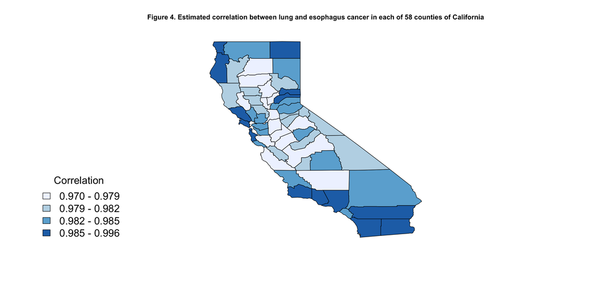

```r
cor_jags = apply(jags_result,1,cor_fun)
cor_jags_est = apply(cor_jags,1,mysummary)

cor_jags_est12 = cor_jags_est[,1:58]
ca.poly$rate12 = cor_jags_est12[1,][order(final_perm)]
ca.poly$sig12 = 0
ca.poly$sig12[which(cor_jags_est12[4,][order(final_perm)] > 0| cor_jags_est12[5,][order(final_perm)]<0)] = 1
brks_fit12 = quantile(ca.poly$rate12)
color.pallete1 = brewer.pal(4,"Blues")
class.rate12 = classIntervals(var=ca.poly$rate12, n=4, style="fixed",
                              fixedBreaks=brks_fit12, dataPrecision=4)
color.code.rate12 = findColours(class.rate12, color.pallete1)
ca.coords = coordinates(ca.poly)
leg.txt = c("0.970 - 0.979", "0.979 - 0.982", "0.982 - 0.985", "0.985 - 0.996")

## Figure 4: Correlation between two diseases in each region
plot(ca.poly, col = color.code.rate12,
     main = "Figure 4. Estimated correlation between lung and esophagus cancer in each of 58 counties of California",
     cex.main=1)
legend("bottomleft", title="Correlation", legend=leg.txt, xpd = TRUE, cex=1.5,
       bty="n", horiz = FALSE, fill = color.pallete1)
```

##### 3.6.4 Posterior mean incidence rates (predictions) for two cancers

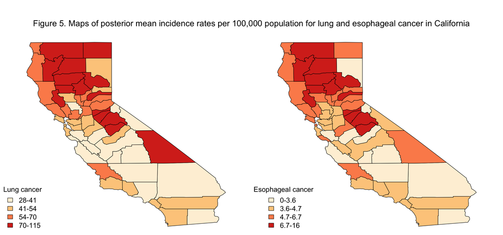

```r
sample.mcmc2 = estimate2$BUGSoutput$sims.array[,1,c(117:136,144:145)]
beta_mcmc = sample.mcmc2[,1:20]

y.est = matrix(0,15000,2*n)
for(iter in 1:15000){
  y.est[iter,] = as.vector(X.o2 %*% as.vector(beta_mcmc[iter,]) + W_mcmc.m2[iter,])
}
y.mean = apply(y.est,2,mean)
ca.poly$rate_lung_est = y.mean[59:116][order(final_perm)]
ca.poly$rate_esophagus_est = y.mean[1:58][order(final_perm)]

brks_fit_lung = c(28, 41, 54, 70, 115)
brks_fit_esophagus = c(0, 3.6, 4.7, 6.7, 16)
color.pallete = brewer.pal(4,"OrRd")
class.rate_lung = classIntervals(var=ca.poly$rate_lung_est, n=4, style="fixed",
                                 fixedBreaks=brks_fit_lung, dataPrecision=4)
class.rate_esophagus = classIntervals(var=ca.poly$rate_esophagus_est, n=4, style="fixed",
                                      fixedBreaks=brks_fit_esophagus, dataPrecision=4)
color.code.rate_lung = findColours(class.rate_lung, color.pallete)
color.code.rate_esophagus = findColours(class.rate_esophagus, color.pallete)



# Figure 5 Plots for posterior mean
par(mfrow=c(1,2), oma = c(0,0,4,0) + 0.1, mar = c(0,0,1,0) + 0.1)

plot(ca.poly, col = color.code.rate_lung)
leg.txt1 = c("28-41", "41-54", "54-70","70-115")
legend("bottomleft", title="Lung cancer", legend=leg.txt1, cex=1.25, bty="n", horiz = FALSE,
       fill = color.pallete)

plot(ca.poly, col = color.code.rate_esophagus)
leg.txt2 = c("0-3.6", "3.6-4.7", "4.7-6.7", "6.7-16")
legend("bottomleft", title="Esophageal cancer", legend=leg.txt2, cex=1.25, bty="n", horiz = FALSE,
       fill = color.pallete)
mtext("Figure 5. Maps of posterior mean incidence rates per 100,000 population for lung and esophageal cancer in California", outer = TRUE, cex = 1.5)
```